# **Panorama da inflação**

# INPC

O Indíce Nacional de Preços ao Consumidor (INPC) variou 1.15% em julho, valor superior ao mesmo período do ano anterior quando apresentou uma taxa de 1.11%. Com esse resultado o indíce acumula no ano uma variação positiva de 4.61%, e em 12 meses uma variação positiva de 9.08%.

|  | 07/2001 | 06/2002 | 07/2002 |
| --- | --- | --- | --- |
| Variação mensal | 1.11% | 0.61% | 1.15% |
| Variação acumulada no ano | 4.96% | 3.42% | 4.61% |
| Variação acumulada em 12 meses | 7.76% | 9.04% | 9.08% |

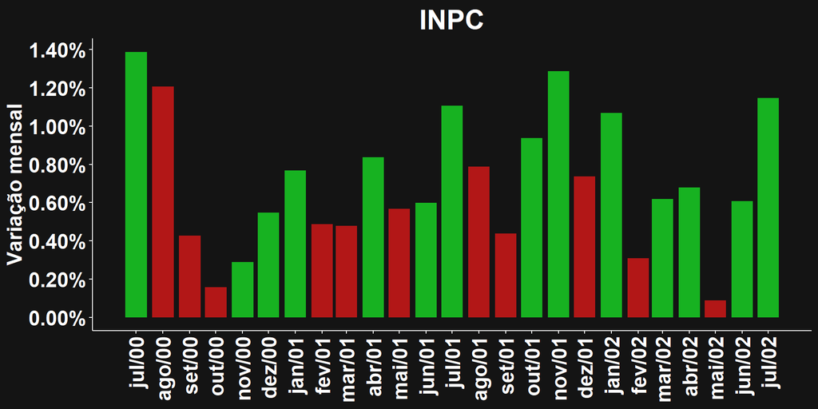

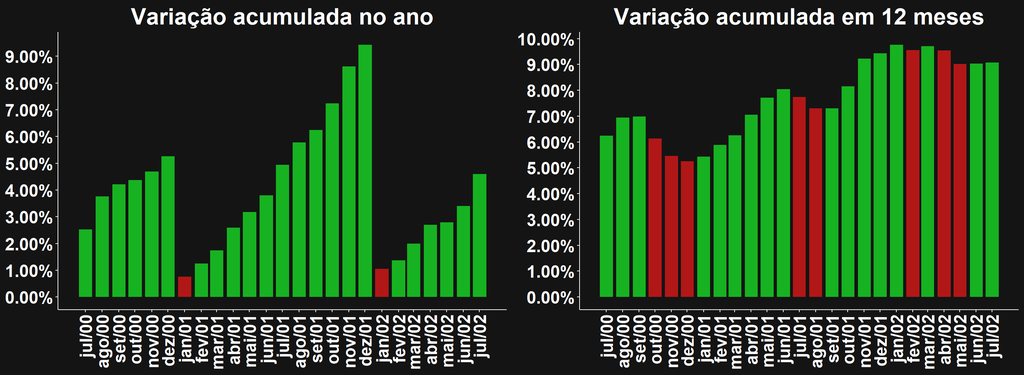

# IGP-M

O Indíce Geral de Preços de Mercado (IGP-M) variou 1.95% em julho, valor superior ao mesmo período do ano anterior quando apresentou uma taxa de 1.48%. Com esse resultado o indíce acumula no ano uma variação positiva de 5.12%, e em 12 meses uma variação positiva de 9.99%.

|  | 07/2001 | 06/2002 | 07/2002 |
| --- | --- | --- | --- |
| Variação mensal | 1.48% | 1.54% | 1.95% |
| Variação acumulada no ano | 5.23% | 3.11% | 5.12% |
| Variação acumulada em 12 meses | 11.09% | 9.48% | 9.99% |

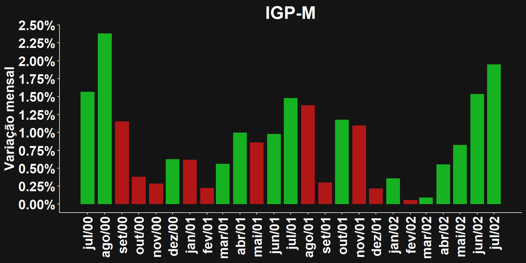

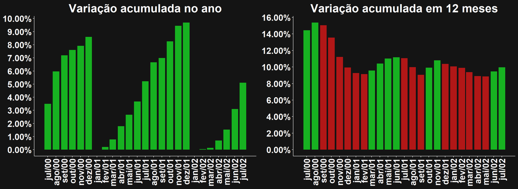